# Thinking Big with Maps in R

## Tips on Wrangling Large Vector Data into Interactive Maps

### Silvia Canelón, PhD

CANSSI Ontario Statistical Software Conference

Nov. 10, 2022

## Navigation

- A **table of contents** for these slides can be accessed by clicking on the hamburger menu icon on the bottom left corner of the screen
- You can navigate the deck:
  - Using the left/right or up/down arrow keys on your keyboard
  - Clicking on the up/down controls in the bottom right corner of the screen

## Silvia Canelón

### Data Analyst @ Penn Urban Health Lab

University of Pennsylvania, Philadelphia, PA, US

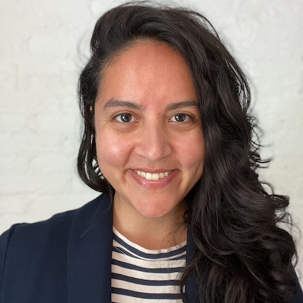

silviacanelon.com  
fosstodon.org/@spcanelon  
[@spcanelon](https://twitter.com/spcanelon)  
[@spcanelon](https://github.com/spcanelon)

## Static map

### Plotting with [geom_sf()](https://ggplot2.tidyverse.org/reference/ggsf.html)

- A lot of lines
- Some large polygons?
- Seems like the entire county was covered by tree canopy

I needed an interactive map to take a closer look at the data

## Which package to use?

- [`leaflet`](https://rstudio.github.io/leaflet/) is best for datasets with <50,000 features…my tree canopy dataset had **193,418** multipolygons
- [`leafgl`](https://github.com/r-spatial/leafgl) is [recommended](https://twitter.com/TimSalabim3/status/1572256658088407042?s=20&t=pXBu5LYTEn5sUueDnlOFTw) in concert with `leaflet` (spoiler: it didn’t work for me)
- settled on `mapview`

## Plotting with [mapview](https://r-spatial.github.io/mapview/)

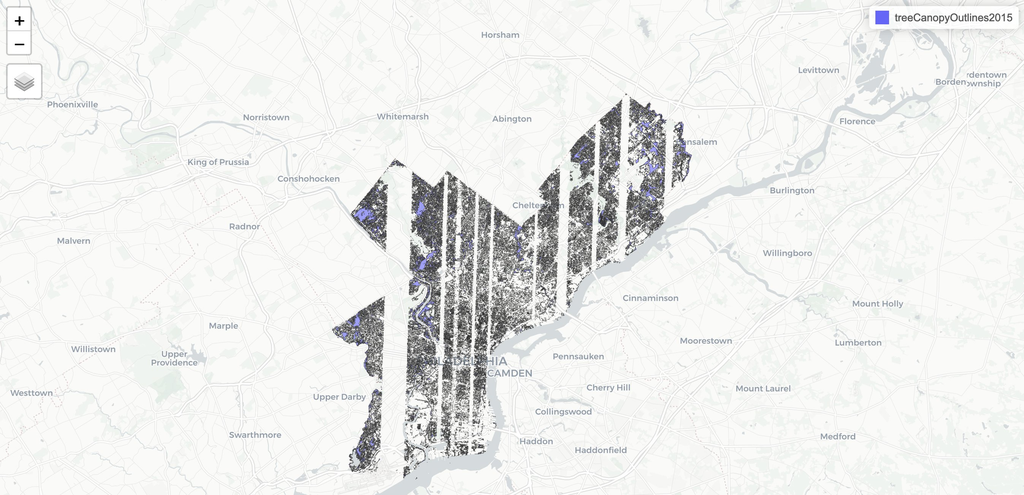

- Vertical strips of data missing
- Non-functional interactivity
- RStudio would crash
- VSCode was hit-or-miss

[figure not shown]

## Suggestion

### Open in [QGIS](https://www.qgis.org/en/site/)

[figure not shown]

[figure not shown]

## Suggestion

### Simplify geometry with rmapshaper

[figure not shown]

## Suggestion

### Try the [tmap](https://r-tmap.github.io/tmap/index.html) package

[figure not shown]

## Suggestion (WIP)

### Try the [rdeck](https://qfes.github.io/rdeck/articles/rdeck.html#scatterplot-map) package

## Thank you #RStats!

[figure not shown]

## Bonus slide!

This slide was added after the presentation to include feedback from talk attendees

- Rendering issues might come from maxing out the RAM
- To reduce the size of the dataset, one could adjust the precision because sometimes the features contain more digits than you need or can meaningfully rely on
- The [mapdeck](https://symbolixau.github.io/mapdeck/articles/mapdeck.html) package might be another one to try. It’s powerful and sits on Mapbox which lets you pull in nice basemaps as well

## Silvia Canelón

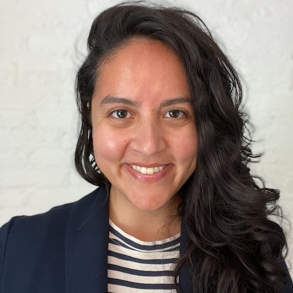

silviacanelon.com  
fosstodon.org/@spcanelon  
[@spcanelon](https://twitter.com/spcanelon)  
[@spcanelon](https://github.com/spcanelon)